# Wie neemt de telefoon op?

Een lokaal SOC en Cyber Academy voor Suriname

Christiaan Verhoef & Erwin Hendriks

16 november 2026

## Mei 2024, Paramaribo

“Het Surinaams overheidsnetwerk ondergaat momenteel malware-aanvallen.” [D1]

De website van e-GOV gaat offline [D2]. DNV-CSIRT start de noodprotocollen, samen met Datasur, Telesur, e-GOV en TAS [D1].

Dit was de overheid, met een eigen CSIRT. Maar wat doet een bank, een ziekenhuis of een leverancier van Staatsolie als het bij hen gebeurt?

Nummers tussen haken verwijzen naar de bewijsmap: online bron, archief, kopie en letterlijk citaat.

## Het antwoord nu: bellen naar het buitenland

Het Academisch Ziekenhuis werd getroffen door ransomware. De ICT Associatie Suriname schrijft over slachtoffers:

> “Bent u eenmaal slachtoffer geworden, dan zult u helaas terug moeten vallen op **dure buitenlandse expertise**” [D4]

En het gebeurt om de hoek. In juli 2025 legt ransomware de Belastingdienst van **Curaçao** plat [K4].

Wie neemt in Paramaribo de telefoon op als het om 2 uur ’s nachts misgaat? Nu: niemand.

# Het probleem

## Suriname is kwetsbaar, en dat is gemeten

| Meting | Uitkomst | Bewijs |
| --- | --- | --- |
| ITU Global Cybersecurity Index 2024 | score 34,78 van 100, laagste groep (T4) | [R1, R2] |
| National Cyber Security Index | 21,67 · plaats 135 | [R2] |
| Opleiding in cybersecurity (NCSI) | **0%** | [R2] |
| Bescherming vitale infrastructuur (NCSI) | **0%** | [R2] |
| Nationale cybercrime-strategie | ontbreekt | [R3] |
| Privacywet | nog een ontwerp | [R4] |
| VS-overheid (OSAC) | kwetsbaar voor banking-trojans, malware, ransomware | [D6] |

## Aanvallen zijn er, maar je ziet de meeste niet

121

unieke ransomware-aanvallen in het Koninkrijk in 2024 [K3]

19%

van de ransomware-aanvallen wordt openbaar gemeld [K5]

In Suriname worden incidenten “niet altijd openbaar gemaakt” [D7]. Bekend: overheidsnetwerk (2024), media-accounts gekaapt (2024), ransomware bij meerdere organisaties (2020) en het AZP [D1–D5].

**Er is geen openbare telling voor Suriname.** Dat cijfer moeten we zelf ophalen bij DNV-CSIRT, banken en de ICT Associatie.

## Wat kost een incident?

USD 2,51 mln

gemiddelde kosten van een datalek in Latijns-Amerika, 2025 [K1]

USD 4,44 mln

wereldwijd gemiddelde, 2025 [K2]

Ter vergelijking: een jaar bewaking met *Wacht Basis* kost circa USD 10.800, ofwel **0,4%** van één gemiddeld lek in de regio.

Eerlijk: de IBM-cijfers komen van grotere bedrijven in Brazilië, Mexico, Chili, Colombia en Argentinië. Een Surinaams bedrijf is kleiner en verliest dus minder in dollars, maar ook relatief meer: geen lokale hulp, dure inhuur van buiten [D4], stroom- en valutaproblemen.

## Waarom nu

| Ontwikkeling | Gevolg voor de vraag | Bewijs |
| --- | --- | --- |
| USD 10,5 mld olie-investering, eerste olie medio 2028 | internationale opdrachtgevers eisen beveiliging van leveranciers | [M2, M3] |
| Nederlandse Cyberbeveiligingswet sinds 15 aug 2026 | Surinaamse leveranciers van Nederlandse klanten krijgen eisen | [M5, D7] |
| Finabank als eerste Surinaamse bank ISO 27001 | banken beginnen te professionaliseren | [R7] |
| Overheid laat ambtenaren opleiden tot SOC-analist | vraag naar opleiding is er al | [C8] |
| Groei rond 4% tot 2028, daarna circa 30% | krappe start, daarna snelle groei | [M1] |

# De oplossing

## Een SOC in Paramaribo, met een eigen opleiding

### SOC: wij houden de wacht

- Bewaking van netwerken, servers en cloud
- Alarm, analyse en eerste ingreep
- Incidentrespons ter plekke, in het Nederlands
- Maandrapport voor directie en toezichthouder

### Cyber Academy: wij leiden op

- SOC-analist in 12 weken, met stage in ons SOC
- IT-team naar security (in-company)
- Bewustwording voor medewerkers

De Academy levert analisten aan het SOC. Het SOC geeft cursisten echte praktijk.

## Pakketten

| Pakket | Wat | Indicatie per maand |
| --- | --- | --- |
| Wacht Basis | werkdagen 08–17, pilotpakket | USD 900 |
| Wacht Plus | 08–24, ’s nachts consignatie | circa USD 1.400 |
| Wacht Continu | 24/7, zodra er 12 klanten zijn | vanaf USD 2.000 |
| Losse diensten | incidentrespons, OSINT-scan, advies, OT | op offerte |
| SOC-analist (12 weken) | per deelnemer | USD 1.500 (te toetsen aan koopkracht) |

Prijzen zijn aannames voor het model (gemiddeld USD 1.700 na de start van 24/7). Te toetsen in gesprekken met pilotklanten.

## Dezelfde nacht, met ons

1. **02:07** Ons systeem ziet een onbekende login op de mailserver van een bank.
2. **02:10** Analist bekijkt het alarm, ziet dat het echt is.
3. **02:15** Telefoon naar de IT-verantwoordelijke van de bank. In het Nederlands, zelfde tijdzone.
4. **02:30** Account geblokkeerd, verbinding afgesloten, bewijs veiliggesteld.
5. **09:00** Rapport bij de directie. Geen vlucht uit Miami, geen losgeld.

Illustratief scenario, geen echt incident.

# Waarom wij

## Waarom dit team het goed gaat doen

### Erwin Hendriks, manager

- Manager Security Operations
- Leidde een 24/7 SOC-team
- Incident responder, teamleider beheer

### Christiaan Verhoef, trainer

- Zette opleidingen en trainersteams op
- Docent ICT, lableider Windesheim
- Field engineer energiesector (BP, Statoil)

## Ons verschil

- **Lokaal en Nederlandstalig**: zelfde taal, tijdzone en wetgeving als de klant
- **Eigen talentpijplijn**: wij lossen het tekort aan analisten zelf op
- **Betaalbaar**: open-source techniek (Wazuh, OpenSearch, TheHive, MISP, Velociraptor)
- **Energie-kennis**: IT én OT, net op tijd voor de oliesector

## Wie is er al?

| Partij | Wat ze doen | Bewijs |
| --- | --- | --- |
| Secmentis | pentests, incidentrespons, managed security | [C1, C2] |
| OX88, Rosheuvel & Partners | IT- en securitydiensten, assessments | [C3, C6] |
| Telesur / Datasur | datacenter, anti-DDoS; NOC wordt “Service Operations Center” (servicebeheer, geen beveiliging) | [C5, C9] |
| e-Government | bouwt eigen SOC, leidt ambtenaren op | [C8] |
| Ekco | SOC’s in Dublin, VK en Maleisië; kantoor Trinidad | [C7] |

**Gat:** geen lokale partij met een commerciële 24/7-bewaking én een opleiding. Datasur en e-Government zijn eerder partner of klant dan concurrent.

# Strategie

## Hoe we groeien

| Fase | Wanneer | Wat | Poort naar de volgende fase |
| --- | --- | --- | --- |
| 0. Voorbereiden | nov 2026 – mrt 2027 | rechtsvorm, partner, intentieverklaringen, SUMS-SU | 3 intentieverklaringen |
| 1. Pilot | 2027 | Wacht Basis bij 3–4 klanten, 3 Academy-cohorten | **6 betalende klanten in maand 12, anders stoppen of bijsturen** |
| 2. Opschalen | 2028 | Wacht Plus, ankerklant, telecompartner als verkoopkanaal | 12 klanten |
| 3. 24/7 | vanaf 12 klanten | Wacht Continu, OT voor de energieketen | positieve kasstroom |

**Verkoopkanalen:** ankerklant (bank of telecom) als referentie · telecompartner verkoopt mee · Academy-cursussen brengen bedrijven binnen · overheid als opleidingsklant [C8].

# Risico’s

## Risicoanalyse

| Risico | Kans | Impact | Wat we doen |
| --- | --- | --- | --- |
| Te weinig klanten: markt nog niet geteld | hoog | hoog | telling per segment; poort in maand 12 |
| Analisten vertrekken naar het buitenland | hoog | middel | eigen opleiding, binding, 25% verloop ingerekend |
| Stroomtekort [M6] | middel | hoog | UPS, generator, back-up in de cloud |
| Krappe economie tot 2028 [M1] | hoog | middel | start klein (8x5), 24/7 pas bij 12 klanten |
| Klanten betalen laat | middel | middel | 2 maanden vertraging ingerekend; prijzen in USD |
| Datasur of overheid bouwt zelf [C8, C9] | middel | hoog | partner worden: opleiding en tweede lijn leveren |
| Aansprakelijkheid na een gemist incident | laag | hoog | heldere contracten, beroepsverzekering |
| Afhankelijk van twee oprichters | middel | hoog | lokale manager vanaf maand 6 ingerekend |

# Financiële projectie

## Drie scenario’s (alleen Suriname, zonder subsidie)

| USD | Tegenvallend | Normaal | Optimistisch |
| --- | --- | --- | --- |
| Omzet 2027 | 40.026 | 73.965 | 91.956 |
| Omzet 2028 | 72.493 | 165.231 | 310.398 |
| Omzet 2029 | 95.319 | 314.193 | 584.605 |
| Resultaat 2027 | -134.374 | -93.235 | -75.244 |
| Resultaat 2028 | -132.123 | -28.537 | 55.335 |
| Resultaat 2029 | -119.619 | 44.425 | 226.155 |
| Klanten eind 2029 | 4 | 15 | 26 |
| Start 24/7 | niet binnen 3 jaar | jul 2029 | jul 2028 |
| Break-even | niet binnen 3 jaar | mrt 2029 | mei 2028 |
| **Financieringsbehoefte** | **468.935** | **245.650** | **202.268** |

Tegenvallend: kleinere markt (25), tragere verkoop, meer uitval, duurdere analisten. Normaal: plan met alle kosten, inclusief oprichters en betaaltermijn. Optimistisch: ankerklant en telecompartner, 24/7 met consignatie. Bron: `model.py`.

## Kaspositie per maand

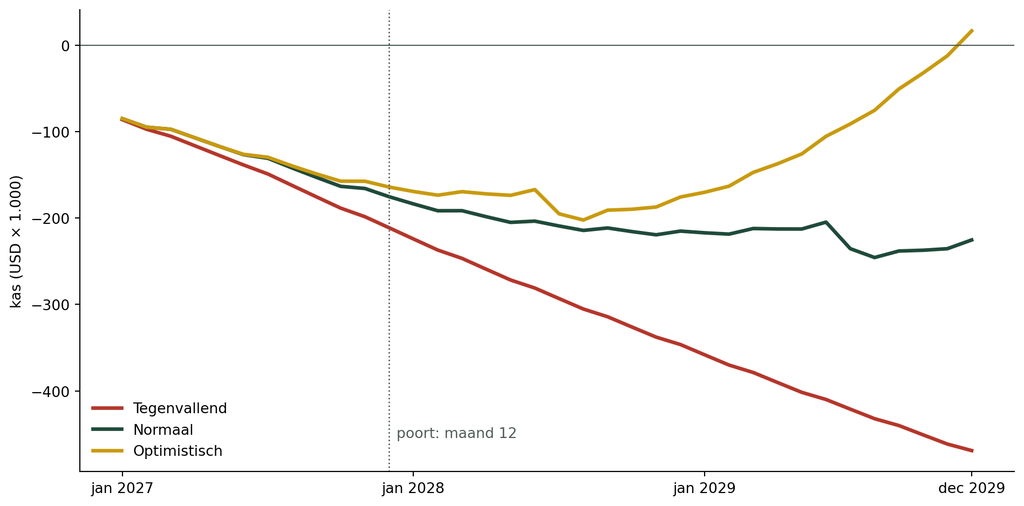

## Wat de cijfers zeggen

- **Normaal:** we hebben circa USD 245.650 nodig. Break-even rond mrt 2029. Bij onzekere aannames (Monte Carlo, 2.000 trekkingen) is de behoefte in 8 van de 10 gevallen lager dan USD 320.889.
- **Optimistisch:** met een ankerklant daalt de behoefte naar USD 202.268 en zijn we in mei 2028 winstgevend.
- **Tegenvallend:** het SOC wordt nooit winstgevend. Daarom de **poort in maand 12**: zijn er dan geen 6 betalende klanten, dan stoppen of omvormen tot alleen Academy. Het verlies blijft dan beperkt tot circa USD 211.288, waarvan USD 75.000 de startinvestering.

Grootste onzekerheid: het aantal bereikbare klanten (45 in het model) is nog **niet** geteld. Subsidie (zie bijlage) zit niet in deze cijfers.

# Wat we nodig hebben

## Oproep

1. **3–4 pilotklanten** met een intentieverklaring, vóór maart 2027
2. **Eén ankerklant**: een bank of telecombedrijf als eerste referentie
3. **Startkapitaal** van circa USD 245.650, met reserve tot USD 320.889
4. **Lokale partner** bevestigd: ruimte, stroom, netwerk, rechtsvorm
5. **Een Surinaamse stichting** als aanvrager voor SUMS-SU (deadline 11 januari 2027)
6. **Introducties** bij DNV-CSIRT, CBvS, Staatsolie-leveranciers en ministeries

Zodat iemand in Paramaribo de telefoon opneemt.

# Bijlagen

## Bijlage A · Subsidies, op volgorde van haalbaarheid

| # | Regeling | Bedrag | Deadline | Kans |
| --- | --- | --- | --- | --- |
| 1 | [SUMS-SU klein](https://www.rvo.nl/subsidies-financiering/sums-su-maatschappelijke-activiteiten) [S1] | €5.000–€25.000 | **11 jan 2027, 17:00** | redelijk |
| 2 | [SUMS-SU groot](https://www.rvo.nl/subsidies-financiering/sums-su-maatschappelijke-activiteiten) [S1] | €25.000–€500.000 | **11 jan 2027, 17:00** | matig |
| 3 | [Makandra-2](https://dwtonline.com/nederland-geeft-opnieuw-10-miljoen-euro-voor-makandra-project/) [S3] | deel van €10 mln | doorlopend, via ministerie | matig |
| 4 | [SUMS-SU Capaciteitsversterking](https://www.rvo.nl/subsidies-financiering/maatschappelijke-initiatieven-slavernijverleden-suriname) | onbekend | ronde nog niet open | onbekend |
| 5 | [DHI Haalbaarheidsstudie](https://www.rvo.nl/subsidies-financiering/dhi-subsidieregeling/dhi-haalbaarheidsstudies) [S2] | 50–70%, max €100.000 | **31 dec 2026** | laag |

SUMS-SU betaalt alleen een **non-profit opleidingsdeel**, niet het commerciële SOC. Geen subsidie maar wel nuttig: EU-project LAC4 met Suriname als projectland [S4], en IDB-aanbestedingen als omzet.

**Wat we per regeling nog moeten doen:** [subsidies-acties.md op GitHub](https://github.com/Suriname-SOC/businessplan/blob/main/subsidies-acties.md)

## Bijlage B · Mogelijke klanten

| Segment | Organisaties (kandidaten) | Waarom zij |
| --- | --- | --- |
| Banken | DSB, Hakrinbank, Finabank [R7], Republic Bank, Southern Commercial Bank, Postspaarbank, Volkskredietbank, Godo | toezicht CBvS [R6], ISO 27001 komt op [R7] |
| Verzekeraars, pensioen | Assuria, Fatum, Self Reliance, Parsasco | persoonsgegevens, toezicht CBvS |
| Telecom en datacenter | Telesur, Datasur [C4, C5], Digicel | partner of klant: tweede lijn, verkoopkanaal |
| Energie en olieketen | Staatsolie [M3], leveranciers van TotalEnergies [M2], EBS | eisen van internationale opdrachtgevers; OT |
| Overheid | e-Government [C8], DNV-CSIRT [D1], ministeries | opleiding en tweede lijn bij incidenten |
| Zorg | AZP [D4], ’s Lands Hospitaal, Diakonessenhuis, SZF | getroffen door ransomware; patiëntgegevens |
| Mijnbouw | Newmont Suriname, Rosebel | internationale moederbedrijven met eisen |
| Leveranciers van NL-klanten | IT, logistiek, administratie | Cyberbeveiligingswet via de klant [M5, D7] |

Namen zonder nummer zijn bekende spelers, nog niet vastgelegd in de bewijsmap. Volgende stap: telling per segment via CBvS-registers en KKF.

## Bijlage C · Bronnen

Elke bewering met een nummer staat in de bewijsmap: bewijs/README.md.

Per nummer: de online bron, een snapshot in het Internet Archive (waar beschikbaar), een lokale kopie (PDF en tekst) met SHA-256, en het letterlijke citaat. Een script controleert bij elke wijziging dat elk citaat echt in de kopie staat.

Verdere onderbouwing: `marktanalyse.qmd`, `concurrentie.qmd`, `review.qmd`, `subsidies.qmd`, financieel model `model.py`.